# IM Project Code

# 0. Load Libraries and Corpus Files

### Prerequisites

To open and use this notebook file you need to install the following:

```r
# intall necessary packages
#install.packages("quanteda")
#install.packages("readtext")
#install.packages("tidyverse")
#install.packages("quanteda.textstats")
#install.packages("quanteda.textplots")
#install.packages("data.table")
#install.packages("stringr")
#install.packages("spacyr")
#install.packages("textcat")

# load libraries
library(quanteda)
library(readtext)
library(tidyverse)
library(quanteda.textplots)
library(quanteda.textstats)
library(spacyr)
library(stringr)
library(data.table)
library(textcat)

spacy_initialize(model = "de_core_news_sm")
```

```
spaCy is already initialized
```

### Load Corpus Files and List of Compounds

(Please make sure that the path is set to the current directory to run this code).

```r
# load corpus files
pro2000 = readRDS("../corpus_data/corpora/pro2000.rds")
contra2000 = readRDS("../corpus_data/corpora/contra2000.rds")

# load list of final climate change compounds
compounds <- scan("../files/wordlist.txt", what="", sep="\n")
```

```
Read 248 items
```

```r
# load list of final climate change compounds and word forms
compound_df <- read.csv("../files/compounds.csv", sep = ";", stringsAsFactors=FALSE)

# lower compounds and word forms
compounds <- tolower(compounds)
compound_df$original <- tolower(compound_df$original)
compound_df$compound_forms <- tolower(compound_df$compound_forms)
```

# 1. Preprocessing

To preprocess the corpora, we perform several steps: stop word removal, lemmazitaion, removal of hyphens

## 1.1 Retrieve Stop Lists

```r
# retrieve stoplists
de_stopwords <- stopwords::stopwords("de", source="snowball")
en_stopwords <- stopwords::stopwords("en", source="snowball" )

# add custom stoplist
custom_stopwords <- c("dass", "=", "the", "seit", "ab", "beim", "\n", "mal", "c", "\\|","|", "m", "kommentare", "neueste", "gepostet", "admin", "cookies", "inhalte", "inhalt", "newsletter", "posten", "zugriff", "passwort", "geschützt", "seite", "website", "webseite", "and", "0", "1", "2", "3","4","5","6","7","8","9", "mfg","w","t","wer","00", "30", ">", "anmelden", "\\+", "40", "81", "erneuerbarer",
"OWLIT", "et", "\\´", "\\^", "tppubtype", "pubstate", "z", "b", "d", "ct", "--")

# combine lists to a full version
full_stopwords <- c(de_stopwords,en_stopwords,custom_stopwords)
```

## 1.2 Lemmatization

Use the `spacy_parse` function to lemmatize the corpus data

```r
# parse the pro corpus with spacy function and retrieve lemma for each token
sp_pro2000 <- spacy_parse(pro2000, pos=FALSE, entity=FALSE, dependency=FALSE)
sp_contra2000 <- spacy_parse(contra2000, pos=FALSE, entity=FALSE, dependency=FALSE)
```

### Manually retrieve lemma form of compound words

Since `spacyr` is not capable of performing a lemmatization of our compound words, we use our manually created list of the word forms for all compound words to retrieve the lemma form.

```r
# function to preprocess compounds data frame
unlist_forms = function(word){
  x <- unlist(strsplit(word, ","))
  return(gsub(" ","",x))}

# retrieve lemma forms for our compound words
# for each compound word
for (words in compound_df$compound_forms){
  word_forms = c(unlist_forms(words)) # put into correct format

  # each word form of the compound word
  for (token in word_forms){

    # retrieve the lemma form
    lemma_form <- compound_df[compound_df$compound_forms %like% token, ]$original[[1]]

    # replace lemma form in pro and contra lemmatized data frame
    # to make sure we get correct lemma form
    sp_pro2000$lemma[tolower(sp_pro2000$token) == token] <- lemma_form
    sp_contra2000$lemma[tolower(sp_contra2000$token) == token] <- lemma_form
    }
}
```

This is still part of spacyr’s lemmatization procedure.

```r
# replace token with lemma - Pro Corpus
sp_pro2000$token <- sp_pro2000$lemma

# replace token with lemma - Contra Corpus
sp_contra2000$token <- sp_contra2000$lemma
```

### Remove Hyphens from Words and Create Tokens Object

Some words contain a hyphen which is being removed in the following step. E.g. “Klima-skeptiker” becomes “Klimaskeptiker”.

```r
# remove hyphens from tokens
sp_p2000_tokens <- as.tokens(sp_pro2000)
toks_comp <- tokens_compound(sp_p2000_tokens, phrase("*-*"), concatenator ="")
toks_hyphenated <- grep("\\w+-\\w+", types(toks_comp), value = TRUE)
sp_p2000_tokens <- tokens_replace(toks_comp, toks_hyphenated, gsub("-", "", toks_hyphenated))

sp_c2000_tokens <- as.tokens(sp_contra2000)
toks_comp <- tokens_compound(sp_c2000_tokens, phrase("*-*"), concatenator ="")
toks_hyphenated <- grep("\\w+-\\w+", types(toks_comp), value = TRUE)
sp_c2000_tokens <- tokens_replace(toks_comp, toks_hyphenated, gsub("-", "", toks_hyphenated))
```

### Apply Preprocessing

```r
# apply preprocessing to pro corpus tokens
sp_p2000_tokens <- sp_p2000_tokens %>%
  tokens(remove_punct = TRUE, remove_numbers = TRUE, remove_symbols = TRUE, remove_url = TRUE,
         remove_separators = TRUE, split_hyphens=FALSE) %>%
  tokens_tolower() %>%
  tokens_remove(pattern = full_stopwords, padding = FALSE)

# apply preprocessing to contra corpus tokens
sp_c2000_tokens <- sp_c2000_tokens %>%
  tokens(remove_punct = TRUE, remove_numbers = TRUE, remove_symbols = TRUE, remove_url = TRUE,
         remove_separators = TRUE, split_hyphens=FALSE) %>%
  tokens_tolower() %>%
  tokens_remove(pattern = full_stopwords, padding = FALSE)
```

## 1.3 Create DFM

In a last step, we generate a Document-Feature-Matrix which we need for the upcoming corpus-based methods.

```r
# create dfm
dfm_p2000_lemma <- dfm(sp_p2000_tokens)
dfm_c2000_lemma <- dfm(sp_c2000_tokens)
```

# 2. Corpus-Based Methods

## 2.1 TF-IDF

Create a function to normalize the TF-IDF scores

```r
# min/max normalization from -1 to 1, relative to data frame results
normalize <- function(x, na.rm = TRUE){
  return((x - min(x)) / (max(x)-min(x)))}
```

And compute TF-IDF of the DFMs

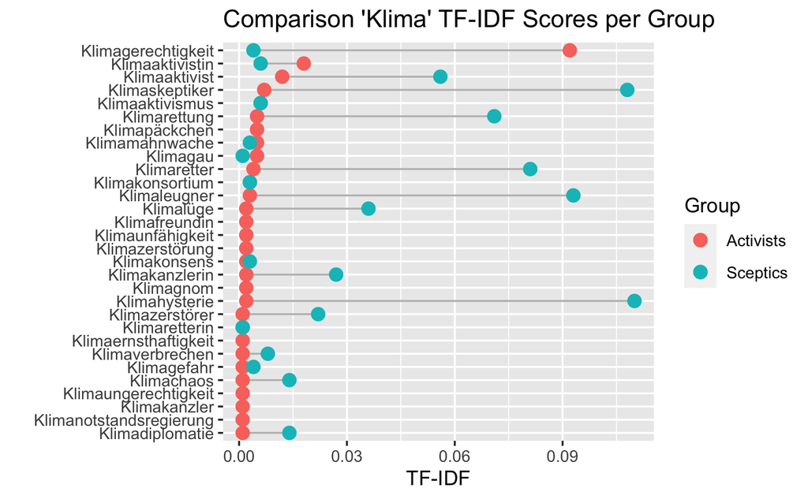

```r
# create a sample of the dfm with all words starting with "klima..."
klima_p2000 <- dfm_select(dfm_p2000_lemma, pattern="klima*")
klima_c2000 <- dfm_select(dfm_c2000_lemma, pattern="klima*")

# calculate tfidf for "klima" words
p2000_tfidf <- dfm_tfidf(klima_p2000, scheme_tf = "prop", scheme_df = "inverse")
c2000_tfidf <- dfm_tfidf(klima_c2000, scheme_tf = "prop", scheme_df = "inverse")

# retrieve frequencies for "klima" words
freqs_pro <- textstat_frequency(p2000_tfidf, force=TRUE)
freqs_con <- textstat_frequency(c2000_tfidf, force=TRUE)

# apply normalization
freqs_pro$normalize = round(normalize(freqs_pro$frequency), 3)
freqs_con$normalize = round(normalize(freqs_con$frequency), 3)

# retrieve only words that are contained in our final compound list
freqs_pro_subset <- freqs_pro[freqs_pro$feature %in% compounds, ]
freqs_pro_subset$feature <- str_to_title(freqs_pro_subset$feature)

freqs_con_subset <- freqs_con[freqs_con$feature %in% compounds, ]
freqs_con_subset$feature <- str_to_title(freqs_con_subset$feature)

# plot comparison of both groups -> only words from compound list
freqs.act <- filter(freqs_pro_subset) %>% as.data.frame() %>% select(feature, normalize)
freqs.scept <- filter(freqs_con_subset) %>% as.data.frame() %>% select(feature, normalize)
freqs <- left_join(freqs.act, freqs.scept, by = "feature") %>% head(30) %>% arrange(normalize.x) %>% mutate(feature = factor(feature, feature))

# create plot
plot8 <- ggplot(freqs) +
    geom_segment(aes(x=feature, xend=feature, y=normalize.x, yend=normalize.y), color="grey") +
    geom_point(aes(x=feature, y=normalize.x, colour="Activists"), size = 3) +
    geom_point(aes(x=feature, y=normalize.y, colour="Sceptics"), size = 3) +
    ggtitle("Comparison 'Klima' TF-IDF Scores per Group") +
    xlab("") + ylab("TF-IDF") +
    coord_flip()

plot8+labs(colour="Group")
```

```r
#ggsave("/Users/anna/Documents/uni/im_glossary/kapitel/plots/comparison_klima_freqs_lemma.png", dpi=300, dev='png', height=6, width=12, units="in")
```

## 2.2 Retrieve Frequencies

```r
# retrieve frequencies
freq_klima_p2000 <- textstat_frequency(klima_p2000)#, n=1000)
freq_klima_c2000 <- textstat_frequency(klima_c2000)#, n=50)

# sort in descending manner
freq_klima_p2000$feature <- with(freq_klima_p2000, reorder(feature, -frequency))
freq_klima_c2000$feature <- with(freq_klima_c2000, reorder(feature, -frequency))

# subset of klima compounds
freq_klima_p2000 <- freq_klima_p2000[freq_klima_p2000$feature %in% compounds, ]
freq_klima_c2000 <- freq_klima_c2000[freq_klima_c2000$feature %in% compounds, ]

freq_klima_p2000
```

|  | feature | frequency | rank | docfreq | group |
| --- | --- | --- | --- | --- | --- |
| 8 | klimagerechtigkeit | 241 | 8 | 124 | all |
| 41 | klimaaktivist | 27 | 41 | 19 | all |
| 45 | klimaaktivistin | 24 | 43 | 18 | all |
| 64 | klimaleugner | 13 | 63 | 6 | all |
| 65 | klimarettung | 13 | 63 | 11 | all |
| 93 | klimakanzlerin | 9 | 91 | 8 | all |
| 102 | klimapäckchen | 8 | 97 | 8 | all |
| 107 | klimahysterie | 8 | 97 | 4 | all |
| 118 | klimakonsortium | 7 | 110 | 6 | all |
| 133 | klimanotstandsregierung | 6 | 123 | 1 | all |

[output cut: 37 more lines]

```r
freq_klima_c2000
```

|  | feature | frequency | rank | docfreq | group |
| --- | --- | --- | --- | --- | --- |
| 11 | klimaleugner | 129 | 11 | 82 | all |
| 14 | klimaskeptiker | 113 | 14 | 67 | all |
| 16 | klimaretter | 103 | 16 | 52 | all |
| 17 | klimaalarmist | 101 | 17 | 67 | all |
| 24 | klimaaktivist | 58 | 24 | 49 | all |
| 26 | klimakirche | 56 | 26 | 32 | all |
| 31 | klimarettung | 49 | 29 | 40 | all |
| 33 | klimahysterie | 48 | 32 | 39 | all |
| 36 | klimarealist | 42 | 36 | 31 | all |
| 40 | klimareligion | 39 | 39 | 28 | all |

[output cut: 136 more lines]

### Get Most Frequent Words per Corpus (TOP-10)

```r
print("PRO TOP-10")
```

```
[1] "PRO TOP-10"
```

```r
head(freq_klima_p2000$feature, 10)
```

```
 [1] klimagerechtigkeit      klimaaktivist           klimaaktivistin
 [4] klimaleugner            klimarettung            klimakanzlerin
 [7] klimapäckchen           klimahysterie           klimakonsortium
[10] klimanotstandsregierung
685 Levels: klimaschutz klimawandel klimapolitisch klima ... klimazukünfte
```

```r
print("CONTRA TOP-10")
```

```
[1] "CONTRA TOP-10"
```

```r
head(freq_klima_c2000$feature, 10)
```

```
 [1] klimaleugner   klimaskeptiker klimaretter    klimaalarmist
 [5] klimaaktivist  klimakirche    klimarettung   klimahysterie
 [9] klimarealist   klimareligion
1728 Levels: klimawandel klima klimaschutz klimamodelle ... klimazystem
```

## 2.3 Keyword-In-Context Analysis

Let’s have a short look at KWIC results for “Klimaleugner”.

```r
# for pro corpus
kwic(sp_p2000_tokens, pattern = phrase("klimaleugner"), window=10, valuetype = "fixed")
```

```
Keyword-in-context with 13 matches.
```

| [fff_de_00135.txt, 631] | eben herde tatsächlich erschlagen wetter äußerst brutal schon immer argument | \| | klimaleugner | \| | ganz sicher ebenso wenig kalt schneereich winter 21. jahrhundert jederzeit |
| --- | --- | --- | --- | --- | --- |
| [fff_de_00019.txt, 4539] | ansteigen verstehen einfluss mensch kleinreden diplomingenieur sollen anstatt afd irgendwelcher | \| | klimaleugner | \| | lieber überwiegend mehrzahl klimaforscher glauben schließlich nutzen sowohl ingenieur klimaforscher |
| [fff_de_00019.txt, 4582] | jahr beeinflussen wohl kaum stand wissenschaft lesen übrig glauben weder | \| | klimaleugner | \| | erwähnt partei wobei verquickung sachthem niveaulos sollen bevor schreiben drüber |
| [fff_de_00019.txt, 5749] | lesen anscheinend bevor selber nachdem selber schon vergessen eigen angabe | \| | klimaleugner | \| | glauben möglicherweise daran aktuell klimawandel selber verursachen stoppen wen glauben |
| [fff_de_00199.txt, 1327] | suv überfahren opis arztbesuch kinderchor liedchen singen umweltsau afd rechtsradikal | \| | klimaleugner | \| | protestieren twittern krachen nrw cduministerpräsident armin laschet redakteure wdr solidarisch |
| [fff_de_00199.txt, 1413] | letztlich weit greta fffbashing unterschiedlich ebene incl. irr kampf gerade | \| | klimaleugner | \| | afd klimaskeptiker springerverlag welt satire ebenfalls letztlich greta fffbashing ausdruck |
| [fff_de_00199.txt, 1426] | springerverlag welt satire ebenfalls letztlich greta fffbashing ausdruck bringen tollhaus | \| | klimaleugner | \| | wenden satire letztlich klimabewegung klimahysterie anprangern deshalb verbohrt ideologe rechtsaußen |
| [fff_de_00199.txt, 1848] | unbedenklichkeit nox dieselabgasen.. sehen muster einseitig berichterstattung ganz sinn | \| | klimaleugner | \| | fall köhler autoindustrie form leugnen wissenschaftlich fakt bevorstehend klimakatastrophe bestehen |
| [fff_de_00199.txt, 2150] | ovarienpres behandeln letztlich frauenfeindlich ideologie heute gegenaufklärerisch charakter gut bestrebung | \| | klimaleugner | \| | passen notwendig klimaschutzmaßnahmus blockieren prof. nina janisch spiegel jury unwort |
| [fff_de_00199.txt, 2220] | sehen radikal auswüchse klimaschutzbewegung stören gemäß kommentar zeit wahr klimahysteriker | \| | klimaleugner | \| | scheinrealität zuletzt gesetz physik pseudowissenschaftlich neu definieren weigerung manch alt |

[output cut: 3 more lines]

```
NA
```

```r
# for contra corpus
kwic(sp_c2000_tokens, pattern = phrase("klimaleugner"), window=10, valuetype = "fixed")
```

```
Keyword-in-context with 129 matches.
```

| [eike_01046.txt, 4488] | anthropogen treibhauseffekt z.b. veröffentlichung falsification beginnen z.b. forderung österreichisch musikprofessor | \| | klimaleugner | \| | todesstrafe fordern fachfremd fanatiker klima soviel verstehen kuh mathematik deutsch |
| --- | --- | --- | --- | --- | --- |
| [eike_06111.txt, 395] | kurz bevor reise beschuldigen abgeordneter bayerisch landtag artikel bekannt tageszeitung | \| | klimaleugner | \| | fake news verbreiten boden seriösen wissenschaftlich argumentieren komplett verlassen schmerzen |
| [eike_11011.txt, 129] | dieselauto suchen geben groß waldfläche wald geben weniger schmal straße | \| | klimaleugner | \| | überhaupt derjenige behaupten derjenige forscher politiker umweltschützer co2und klimakatastrophe ausdachen |
| [eike_04677.txt, 2] | spaßvogel | \| | klimaleugner | \| | fordern ja bereits solidarität klimaschütz fridays futuren sämtlich kohlekraftwerk freitags |
| [eike_00251.txt, 779] | völlig transparent mission impossible funktionieren wirklich professor michael merrifield sicher | \| | klimaleugner | \| | erklären konsequenz logik erkennen kurzversion treibhausgase verschieben zone ir abstrahlung |
| [eike_05911.txt, 8100] | begreifen global realisierung groß transformation global sinn schwierig angelegenheit bedeuten | \| | klimaleugner | \| | innen geben groß transformation schnell voran gehen hysterische schreihälse lösen |
| [eike_00394.txt, 15] | interpretation aussage samoas premierminister tuilaepa sailele kürzlich rede tätigen wut | \| | klimaleugner | \| | ausdruck bringen fordern anstalt einzuweisen schließlich sicher untergang atoll verantworten |
| [eike_03371.txt, 608] | zweifel richtigkeit behauptung aufgrund extrem dünn faktenbasi treffen schlimm vergleichen | \| | klimaleugner | \| | mensch bauchschmerz bekommen parlamentarismus gewiß grundrecht einschränken begründung corona obwohl |
| [eike_04925.txt, 2] | psychologie | \| | klimaleugner | \| | teil iii kurz beginnen klein reihe strategie psychologisch diffamierung klimaskeptiker |
| [eike_13377.txt, 355] | lange atmosphäre erde geben schüler klugscheißer schüler komm gehen schüler | \| | klimaleugner | \| | nein klimarealist wahrscheinlich intensiv befasst demonstrieren schüler müssen prozent bleiben |

[output cut: 119 more lines]

```
NA
```

## 2.4 Collocations

To check the collocations of a compound word, we firstly retrieve the context of the word via KWIC with a window of 1 (because we are looking for bigrams). Then we count the words preceding and following the keyword.

Pro Corpus

```r
# apply keyword-in-context function for given word
kwic_pro <- kwic(sp_p2000_tokens, pattern = phrase("klimakrise"), window=1, valuetype = "regex") %>%
  as_tibble()

kwic_pro %>%
  count(pre) %>%
  arrange(desc(n))
```

| pre | n |
| --- | --- |
| stark | 11 |
| bewältigung | 8 |
| mitten | 8 |
| verantwortung | 6 |
| auswirkung | 5 |
| bekämpfung | 5 |
| umgang | 5 |
|  | 4 |
| aufgrund | 4 |
| bedrohung | 4 |

[output cut: 195 more lines]

```r
kwic_pro %>%
  count(post) %>%
  arrange(desc(n))
```

| post | n |
| --- | --- |
| betreffen | 10 |
| leisten | 6 |
| mehr | 6 |
| übernehmen | 6 |
| befinden | 5 |
| groß | 5 |
| abwenden | 4 |
| bereits | 4 |
| müssen | 4 |
| stoppen | 4 |

[output cut: 198 more lines]

Contra Corpus

```r
# apply keyword-in-context function for given word
kwic_con <- kwic(sp_c2000_tokens, pattern = phrase("klimakrise"), window=1, valuetype = "regex") %>%
  as_tibble()

kwic_con %>%
  count(pre) %>%
  arrange(desc(n))
```

| pre | n |
| --- | --- |
| wirklich | 3 |
| behaupten | 1 |
| behauptung | 1 |
| beispiel | 1 |
| bekämpfung | 1 |
| daran | 1 |
| darauf | 1 |
| dramatisch | 1 |
| energiewende | 1 |
| erfinden | 1 |

[output cut: 29 more lines]

```r
kwic_con %>%
  count(post) %>%
  arrange(desc(n))
```

| post | n |
| --- | --- |
| global | 3 |
| ja | 3 |
| abwehren | 1 |
| angst | 1 |
| auseinandersetzen | 1 |
| auswirkung | 1 |
| auszuleben | 1 |
| bedrohung | 1 |
| befinden | 1 |
| beitragen | 1 |

[output cut: 27 more lines]

# 3. Add Data to Corpus

## 3.1 Load New Text Files and Create Corpus Object

(To run this code, please unzip `corpus_data/text_files.zip` and `corpus_data/corpora.zip` files first.)

```r
# add farn to pro2000
# add klimaschwindel to contra2000
# add compact to contra2000

### NF-FARN.DE
# load climate change activists texts
farn_texts <- readtext("../corpus_data/text_files/pro/farn_texts/*") # /* is used to retrieve all files inside the directory

# create corpus
farn_corpus <- corpus(farn_texts)
docvars(farn_corpus, "origin") <- "farn" # change string to your desired origin tag
docvars(farn_corpus, "language") <- textcat(farn_corpus)

# drop all non german texts
farn_corpus <- corpus_subset(farn_corpus, language == "german", drop_docid = TRUE)

### COMPACT MAGAZIN
compact_texts <- readtext("../corpus_data/text_files/contra/compact_texts/*")

# create corpus
compact_corpus <- corpus(compact_texts)
docvars(compact_corpus, "origin") <- "compact" # change string to your desired origin tag
docvars(compact_corpus, "language") <- textcat(compact_corpus)

# drop all non german texts
compact_corpus <- corpus_subset(compact_corpus, language == "german", drop_docid = TRUE)

### Klimaschwindel Website

klimaschwindel_texts <- readtext("../corpus_data/text_files/contra/klimaschwindel_texts/*")

# create corpus
klimaschwindel_corpus <- corpus(klimaschwindel_texts)
docvars(klimaschwindel_corpus, "origin") <- "klimaschwindel" # change string to your desired origin tag
docvars(klimaschwindel_corpus, "language") <- textcat(klimaschwindel_corpus)

# drop all non german texts
klimaschwindel_corpus <- corpus_subset(klimaschwindel_corpus, language == "german", drop_docid = TRUE)
```

## 3.2 Merge New Corpus Texts with Old Corpora

```r
# add to previous corpus
pro2022 <- pro2000 + farn_corpus
contra2022 <- contra2000 + compact_corpus + klimaschwindel_corpus

# create docvars
docvars(contra2022, "group") <- "sceptics"
docvars(pro2022, "group") <- "activists"
```

## 3.3 Save Corpus Objects

```r
#saveRDS(pro2022, "pro2022.rds")
#saveRDS(contra2022, "contra2022.rds")

# Run this to get corpus overview asl CSV file
#write.csv(summary(pro2022, n=ndoc(pro2022)), "corpus/pro2022_overview.csv")
#write.csv(summary(contra2022, n=ndoc(contra2022)), "corpus/contra2022_overview.csv")
```

## 3.4 Retrieve New Corpus Statistics

### 3.4.1 Average Number of Sentences per Text

```r
# load corpus files
pro2022 = readRDS("/Users/anna/Documents/uni/im_project/corpus_data/corpora/pro2022.rds")
contra2022 = readRDS("/Users/anna/Documents/uni/im_project/corpus_data/corpora/contra2022.rds")
```

```r
# get mean of sentences count for corpus
sentences = summary(pro2022, n=ndoc(pro2022))$Sentences
mean(sentences)
```

```
[1] 24.45842
```

```r
# get mean of sentences count for corpus
sentences = summary(contra2022, n=ndoc(contra2022))$Sentences
mean(sentences)
```

```
[1] 75.89438
```

### 3.4.2 Token Count for each Corpus

```r
sum(summary(contra2022, n=ndoc(contra2022))$Tokens)
```

```
[1] 3190338
```

```r
sum(summary(pro2022, n=ndoc(pro2022))$Tokens)
```

```
[1] 1235021
```